# Tarea4_Ricardo_Garbanzo3

# Ejercicio 3

3. [20 puntos] Para esta pregunta usaremos nuevamente los datos Datos Churn.csv. Usando el paquete traineR realice lo siguiente:

A ) El objetivo de este ejercicio es calibrar el metodo de kknn para esta Tabla de Datos. Aquı interesa predecir en la variable DejaBanco que indica si el cliente deja sus negocios con el banco (1) o no (0). Para esto genere 5 Validaciones Cruzadas con 10 grupos calibrando■ el modelo de acuerdo con todos los tipos de algoritmos que permite train.kknn en el parametro kernel, estos algoritmos son: rectangular, triangular, epanechnikov, biweight, triweight, cos, inv, gaussian y optimal. Para medir la calidad de metodo sume la cantidad de 1’s detectados en los diferentes grupos. Luego grafique las 5 iteraciones para todos algoritmos en el mismo grafico. ¿Se puede determinar con claridad cual algoritmo es el mejor? Para generar los modelos predictivos use el paquete traineR.

```r
library(caret)
library(traineR)
datos <- read.csv("Datos_Churn.csv",header=TRUE, sep=",", dec=".")
datos <- datos[, -c(1,4,2,7)]
datos <- na.omit(datos)

datos$TarjetaCredito <- factor(datos$TarjetaCredito, ordered = T)
datos$Activo <- factor(datos$Activo, ordered = T)
datos$DejaBanco <- factor(datos$DejaBanco, ordered = T)
str(datos)
```

```
## 'data.frame':    9845 obs. of  9 variables:
##  $ ScoringCrediticio: int  769 793 746 670 644 787 611 850 445 675 ...
##  $ Genero           : Factor w/ 2 levels "Femenino","Masculino": 2 1 2 1 2 1 1 2 1 1 ...
##  $ Edad             : int  43 63 58 54 30 42 40 40 34 32 ...
##  $ BalanceCuenta    : num  110183 116271 0 95507 44929 ...
##  $ CantidadProductos: int  2 1 3 1 1 2 1 2 2 1 ...
##  $ TarjetaCredito   : Ord.factor w/ 2 levels "0"<"1": 2 2 2 2 2 1 2 1 2 2 ...
##  $ Activo           : Ord.factor w/ 2 levels "0"<"1": 2 2 2 2 2 2 1 2 2 1 ...
##  $ SalarioEstimado  : num  87537 184243 80345 63213 10771 ...
##  $ DejaBanco        : Ord.factor w/ 2 levels "0"<"1": 1 1 2 1 1 1 1 1 1 1 ...
##  - attr(*, "na.action")= 'omit' Named int  45 61 107 201 228 239 308 390 405 531 ...
##   ..- attr(*, "names")= chr  "45" "61" "107" "201" ...
```

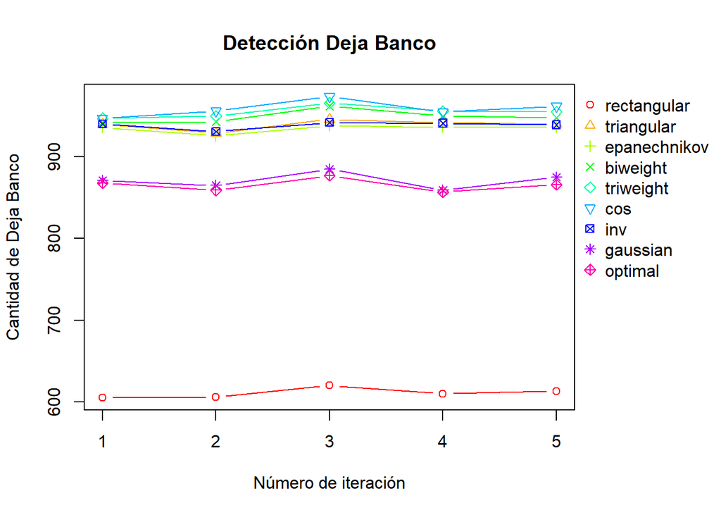

```r
numero.filas <- nrow(datos)
cantidad.validacion.cruzada <- 5
cantidad.grupos <- 10


deteccion.si.rectangular <- c()
deteccion.si.triangular <- c()
deteccion.si.epanechnikov <- c()
deteccion.si.biweight <- c()
deteccion.si.triweight <- c()
deteccion.si.cos <- c()
deteccion.si.inv <- c()
deteccion.si.gaussian <- c()
deteccion.si.optimal <- c()

for(i in 1:cantidad.validacion.cruzada){
  grupos  <- createFolds(1:numero.filas, cantidad.grupos)
  si.rectangular <- 0
  si.triangular <- 0
  si.epanechnikov <- 0
  si.biweight <- 0
  si.triweight <- 0
  si.cos <- 0
  si.inv <- 0
  si.gaussian <- 0
  si.optimal <- 0


  for(k in 1:cantidad.grupos) {
    muestra <- grupos[[k]]
    ttesting <- datos[muestra, ]
    taprendizaje <- datos[-muestra, ]

    modelo <- train.knn(formula = DejaBanco~., data = taprendizaje, kmax = 3, kernel = "rectangular")
    prediccion <- predict(modelo, ttesting)
    MC <- confusion.matrix(ttesting, prediccion)
    si.rectangular <- si.rectangular + MC[2, 2] # Detección DejaBanco

    modelo <- train.knn(formula = DejaBanco~., data = taprendizaje, kmax = 3, kernel = "triangular")
    prediccion <- predict(modelo, ttesting)
    MC <- confusion.matrix(ttesting, prediccion)
    si.triangular <- si.triangular + MC[2, 2] # Detección DejaBanco

    modelo <- train.knn(formula = DejaBanco~., data = taprendizaje, kmax = 3, kernel = "epanechnikov")
    prediccion <- predict(modelo, ttesting)
    MC <- confusion.matrix(ttesting, prediccion)
    si.epanechnikov <- si.epanechnikov + MC[2, 2] # Detección DejaBanco

    modelo <- train.knn(formula = DejaBanco~., data = taprendizaje, kmax = 3, kernel = "biweight")
    prediccion <- predict(modelo, ttesting)
    MC <- confusion.matrix(ttesting, prediccion)
    si.biweight <- si.biweight + MC[2, 2] # Detección DejaBanco

    modelo <- train.knn(formula = DejaBanco~., data = taprendizaje, kmax = 3, kernel = "triweight")
    prediccion <- predict(modelo, ttesting)
    MC <- confusion.matrix(ttesting, prediccion)
    si.triweight <- si.triweight + MC[2, 2] # Detección DejaBanco

    modelo <- train.knn(formula = DejaBanco~., data = taprendizaje, kmax = 3, kernel = "cos")
    prediccion <- predict(modelo, ttesting)
    MC <- confusion.matrix(ttesting, prediccion)
    si.cos <- si.cos + MC[2, 2] # Detección DejaBanco

    modelo <- train.knn(formula = DejaBanco~., data = taprendizaje, kmax = 3, kernel = "inv")
    prediccion <- predict(modelo, ttesting)
    MC <- confusion.matrix(ttesting, prediccion)
    si.inv <- si.inv + MC[2, 2] # Detección DejaBanco

    modelo <- train.knn(formula = DejaBanco~., data = taprendizaje, kmax = 3, kernel = "gaussian")
    prediccion <- predict(modelo, ttesting)
    MC <- confusion.matrix(ttesting, prediccion)
    si.gaussian <- si.gaussian + MC[2, 2] # Detección DejaBanco

    modelo <- train.knn(formula = DejaBanco~., data = taprendizaje, kmax = 3, kernel = "optimal")
    prediccion <- predict(modelo, ttesting)
    MC <- confusion.matrix(ttesting, prediccion)
    si.optimal <- si.optimal + MC[2, 2] # Detección DejaBanco
  }


  deteccion.si.rectangular[i] <- si.rectangular
  deteccion.si.triangular[i] <- si.triangular
  deteccion.si.epanechnikov[i] <- si.epanechnikov
  deteccion.si.biweight[i] <- si.biweight
  deteccion.si.triweight[i] <- si.triweight
  deteccion.si.cos[i] <- si.cos
  deteccion.si.inv[i] <- si.inv
  deteccion.si.gaussian[i] <- si.gaussian
  deteccion.si.optimal[i] <- si.optimal


}


resultados <- data.frame("rectangular" = deteccion.si.rectangular,
                         "triangular" = deteccion.si.triangular,
                         "epanechnikov" = deteccion.si.epanechnikov,
                         "biweight" = deteccion.si.biweight,
                         "triweight" = deteccion.si.triweight,
                         "cos" = deteccion.si.optimal,
                         "inv" = deteccion.si.cos,
                         "gaussian" = deteccion.si.inv,
                         "optimal" = deteccion.si.gaussian)

par(oma=c(0, 0, 0, 5)) # Hace espacio para la leyenda

matplot(resultados, type="b", lty = 1, lwd = 1, pch = 1:ncol(resultados),
        main = "Detección Deja Banco",
        xlab = "Número de iteración",
        ylab = "Cantidad de Deja Banco",
        col = rainbow(ncol(resultados)))
legend(par('usr')[2], par('usr')[4], legend = colnames(resultados),bty='n', xpd=NA,
       pch=1:ncol(resultados), col = rainbow(ncol(resultados))) # La leyenda
```

## Punto B

[figure not shown]

# Punto C

El algoritmo rectangular presenta un menor error global claramente visible en el gráfico, mas no así mejor asierto del Sí.